# Smart devices case study

## Loading libraries

```r
library(dplyr)
library(tidyverse)
library(ggplot2)
```

## Loading CSV files

Create dataframes for daily activity, daily steps, daily calories, sleep day datasets.

```r
setwd("C:/Users/Admin/Documents/GitHub/Smart-devices/")
daily_activity <- read.csv("dailyActivity_merged.csv")
daily_steps <- read.csv("dailySteps_merged.csv")
daily_calories <- read.csv("dailyCalories_merged.csv")
sleep_day <- read.csv("sleepDay_merged.csv")
```

## Exploring a few key tables

Take a look at the tables.

```r
head(daily_activity)
```

```
##           Id ActivityDate TotalSteps TotalDistance TrackerDistance
## 1 1503960366    4/12/2016      13162          8.50            8.50
## 2 1503960366    4/13/2016      10735          6.97            6.97
## 3 1503960366    4/14/2016      10460          6.74            6.74
## 4 1503960366    4/15/2016       9762          6.28            6.28
## 5 1503960366    4/16/2016      12669          8.16            8.16
## 6 1503960366    4/17/2016       9705          6.48            6.48
##   LoggedActivitiesDistance VeryActiveDistance ModeratelyActiveDistance
## 1                        0               1.88                     0.55
## 2                        0               1.57                     0.69
## 3                        0               2.44                     0.40
## 4                        0               2.14                     1.26
## 5                        0               2.71                     0.41
## 6                        0               3.19                     0.78
##   LightActiveDistance SedentaryActiveDistance VeryActiveMinutes
## 1                6.06                       0                25
## 2                4.71                       0                21
## 3                3.91                       0                30
## 4                2.83                       0                29
## 5                5.04                       0                36
## 6                2.51                       0                38
##   FairlyActiveMinutes LightlyActiveMinutes SedentaryMinutes Calories
## 1                  13                  328              728     1985
## 2                  19                  217              776     1797
## 3                  11                  181             1218     1776
## 4                  34                  209              726     1745
## 5                  10                  221              773     1863
## 6                  20                  164              539     1728
```

```r
head(daily_steps)
```

```
##           Id ActivityDay StepTotal
## 1 1503960366   4/12/2016     13162
## 2 1503960366   4/13/2016     10735
## 3 1503960366   4/14/2016     10460
## 4 1503960366   4/15/2016      9762
## 5 1503960366   4/16/2016     12669
## 6 1503960366   4/17/2016      9705
```

```r
head(daily_calories)
```

```
##           Id ActivityDay Calories
## 1 1503960366   4/12/2016     1985
## 2 1503960366   4/13/2016     1797
## 3 1503960366   4/14/2016     1776
## 4 1503960366   4/15/2016     1745
## 5 1503960366   4/16/2016     1863
## 6 1503960366   4/17/2016     1728
```

```r
head(sleep_day)
```

```
##           Id              SleepDay TotalSleepRecords TotalMinutesAsleep
## 1 1503960366 4/12/2016 12:00:00 AM                 1                327
## 2 1503960366 4/13/2016 12:00:00 AM                 2                384
## 3 1503960366 4/15/2016 12:00:00 AM                 1                412
## 4 1503960366 4/16/2016 12:00:00 AM                 2                340
## 5 1503960366 4/17/2016 12:00:00 AM                 1                700
## 6 1503960366 4/19/2016 12:00:00 AM                 1                304
##   TotalTimeInBed
## 1            346
## 2            407
## 3            442
## 4            367
## 5            712
## 6            320
```

Identify all the columns in the daily_activity data.

```r
colnames(daily_activity)
```

```
##  [1] "Id"                       "ActivityDate"
##  [3] "TotalSteps"               "TotalDistance"
##  [5] "TrackerDistance"          "LoggedActivitiesDistance"
##  [7] "VeryActiveDistance"       "ModeratelyActiveDistance"
##  [9] "LightActiveDistance"      "SedentaryActiveDistance"
## [11] "VeryActiveMinutes"        "FairlyActiveMinutes"
## [13] "LightlyActiveMinutes"     "SedentaryMinutes"
## [15] "Calories"
```

Identify all the columns in the sleep data.

```r
colnames(sleep_day)
```

```
## [1] "Id"                 "SleepDay"           "TotalSleepRecords"
## [4] "TotalMinutesAsleep" "TotalTimeInBed"
```

## Understanding some summary statistics

How many unique participants are there in each dataframe?

```r
n_distinct(daily_activity$Id)
```

```
## [1] 33
```

```r
n_distinct(sleep_day$Id)
```

```
## [1] 24
```

```r
n_distinct(daily_steps$Id)
```

```
## [1] 33
```

```r
n_distinct(daily_calories$Id)
```

```
## [1] 33
```

There are more paticipants in the daily activity, steps, calories dataset (33) than the sleep dataset (24).

How many observations are there in each dataframe?

```r
nrow(daily_activity)
```

```
## [1] 940
```

```r
nrow(sleep_day)
```

```
## [1] 413
```

```r
nrow(daily_steps)
```

```
## [1] 940
```

```r
nrow(daily_calories)
```

```
## [1] 940
```

Inspect the dataframes.

```r
str(daily_activity)
```

```
## 'data.frame':    940 obs. of  15 variables:
##  $ Id                      : num  1.5e+09 1.5e+09 1.5e+09 1.5e+09 1.5e+09 ...
##  $ ActivityDate            : chr  "4/12/2016" "4/13/2016" "4/14/2016" "4/15/2016" ...
##  $ TotalSteps              : int  13162 10735 10460 9762 12669 9705 13019 15506 10544 9819 ...
##  $ TotalDistance           : num  8.5 6.97 6.74 6.28 8.16 ...
##  $ TrackerDistance         : num  8.5 6.97 6.74 6.28 8.16 ...
##  $ LoggedActivitiesDistance: num  0 0 0 0 0 0 0 0 0 0 ...
##  $ VeryActiveDistance      : num  1.88 1.57 2.44 2.14 2.71 ...
##  $ ModeratelyActiveDistance: num  0.55 0.69 0.4 1.26 0.41 ...
##  $ LightActiveDistance     : num  6.06 4.71 3.91 2.83 5.04 ...
##  $ SedentaryActiveDistance : num  0 0 0 0 0 0 0 0 0 0 ...
##  $ VeryActiveMinutes       : int  25 21 30 29 36 38 42 50 28 19 ...
##  $ FairlyActiveMinutes     : int  13 19 11 34 10 20 16 31 12 8 ...
##  $ LightlyActiveMinutes    : int  328 217 181 209 221 164 233 264 205 211 ...
##  $ SedentaryMinutes        : int  728 776 1218 726 773 539 1149 775 818 838 ...
##  $ Calories                : int  1985 1797 1776 1745 1863 1728 1921 2035 1786 1775 ...
```

```r
str(sleep_day)
```

```
## 'data.frame':    413 obs. of  5 variables:
##  $ Id                : num  1.5e+09 1.5e+09 1.5e+09 1.5e+09 1.5e+09 ...
##  $ SleepDay          : chr  "4/12/2016 12:00:00 AM" "4/13/2016 12:00:00 AM" "4/15/2016 12:00:00 AM" "4/16/2016 12:00:00 AM" ...
##  $ TotalSleepRecords : int  1 2 1 2 1 1 1 1 1 1 ...
##  $ TotalMinutesAsleep: int  327 384 412 340 700 304 360 325 361 430 ...
##  $ TotalTimeInBed    : int  346 407 442 367 712 320 377 364 384 449 ...
```

```r
str(daily_steps)
```

```
## 'data.frame':    940 obs. of  3 variables:
##  $ Id         : num  1.5e+09 1.5e+09 1.5e+09 1.5e+09 1.5e+09 ...
##  $ ActivityDay: chr  "4/12/2016" "4/13/2016" "4/14/2016" "4/15/2016" ...
##  $ StepTotal  : int  13162 10735 10460 9762 12669 9705 13019 15506 10544 9819 ...
```

```r
str(daily_calories)
```

```
## 'data.frame':    940 obs. of  3 variables:
##  $ Id         : num  1.5e+09 1.5e+09 1.5e+09 1.5e+09 1.5e+09 ...
##  $ ActivityDay: chr  "4/12/2016" "4/13/2016" "4/14/2016" "4/15/2016" ...
##  $ Calories   : int  1985 1797 1776 1745 1863 1728 1921 2035 1786 1775 ...
```

The id columns are now num, so I convert them to character so that they can stack correctly and I can join them later on.

```r
daily_activity <-  mutate(daily_activity, Id= as.character(Id))
sleep_day <-  mutate(sleep_day, Id = as.character(Id))
daily_steps <-  mutate(daily_steps, Id = as.character(Id))
daily_calories <-  mutate(daily_calories, Id = as.character(Id))
```

I have a look at summary statistics about each data.

For the daily activity dataframe:

```r
daily_activity %>%
  select(TotalSteps,
         TotalDistance,
         SedentaryMinutes) %>%
  summary()
```

```
##    TotalSteps    TotalDistance    SedentaryMinutes
##  Min.   :    0   Min.   : 0.000   Min.   :   0.0
##  1st Qu.: 3790   1st Qu.: 2.620   1st Qu.: 729.8
##  Median : 7406   Median : 5.245   Median :1057.5
##  Mean   : 7638   Mean   : 5.490   Mean   : 991.2
##  3rd Qu.:10727   3rd Qu.: 7.713   3rd Qu.:1229.5
##  Max.   :36019   Max.   :28.030   Max.   :1440.0
```

Key findings:

- The average sedentary time is 991 minutes (~16 hour).
- Participants walk 7638 steps a day on average which is more than the average American (3000-4000 steps).

For the sleep dataframe:

```r
sleep_day %>%
  select(TotalSleepRecords,
  TotalMinutesAsleep,
  TotalTimeInBed) %>%
  summary()
```

```
##  TotalSleepRecords TotalMinutesAsleep TotalTimeInBed
##  Min.   :1.000     Min.   : 58.0      Min.   : 61.0
##  1st Qu.:1.000     1st Qu.:361.0      1st Qu.:403.0
##  Median :1.000     Median :433.0      Median :463.0
##  Mean   :1.119     Mean   :419.5      Mean   :458.6
##  3rd Qu.:1.000     3rd Qu.:490.0      3rd Qu.:526.0
##  Max.   :3.000     Max.   :796.0      Max.   :961.0
```

Key findings:

- There are 3 sleep records on maximum a day.
- The average time asleep is 419 minutes while the average time in bed is 458.
- This sample of people’s activities indicates that people’s time in bed is more than their actual sleep time.

## Plotting a few explorations

What’s the relationship between steps taken in a day and sedentary minutes?

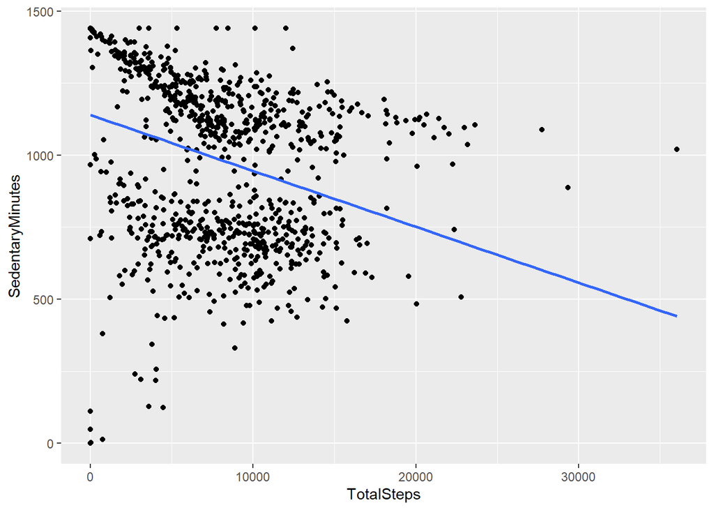

```r
ggplot(daily_activity, aes(x=TotalSteps, y=SedentaryMinutes)) + geom_point()+
  geom_smooth(formula = y ~ x, method="lm", se = FALSE)
```

```r
# correlation test
cor.test(daily_activity$TotalSteps, daily_activity$SedentaryMinutes)
```

```
##
##  Pearson's product-moment correlation
##
## data:  daily_activity$TotalSteps and daily_activity$SedentaryMinutes
## t = -10.615, df = 938, p-value < 2.2e-16
## alternative hypothesis: true correlation is not equal to 0
## 95 percent confidence interval:
##  -0.3833971 -0.2691782
## sample estimates:
##        cor
## -0.3274835
```

Steps taken in a day have a negative relationship with sedentary minutes and the relationship is statistically significant.

What’s the relationship between minutes asleep and time in bed?

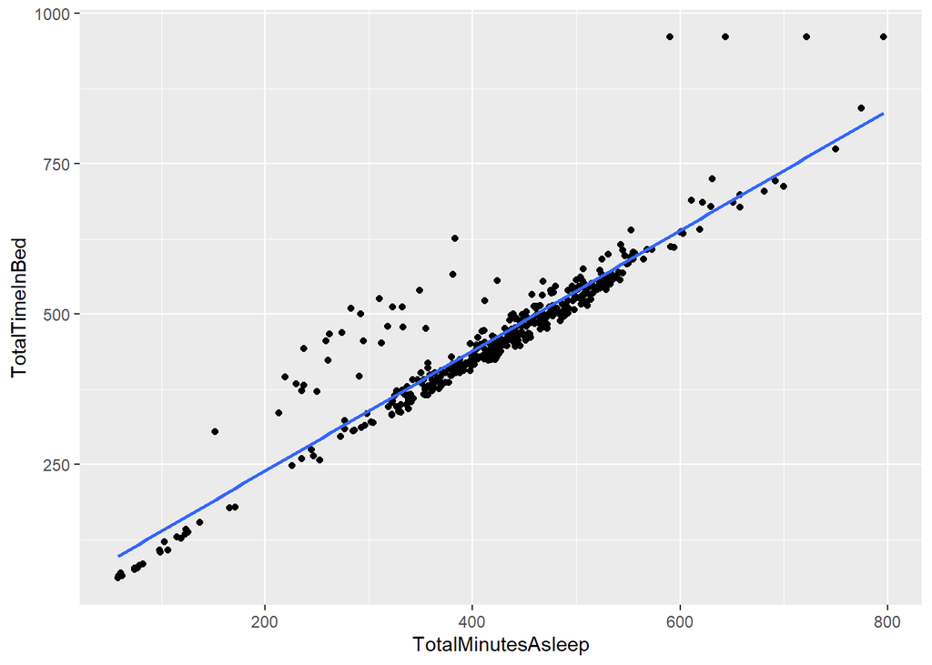

```r
ggplot(data=sleep_day, aes(x=TotalMinutesAsleep, y=TotalTimeInBed)) + geom_point() +
  geom_smooth(formula = y ~ x,method="lm", se=FALSE)
```

There is a positive relationship between total minutes asleep and total time in bed. The company can use this trend to market the wellness watch “Time” as a way to track total minutes asleep and suggest needed time in bed so that woman can achieve their desired sleep time.

## Merging these two datasets together

```r
combined_data <- merge(sleep_day, daily_activity, by="Id")
```

Take a look at how many participants are in this data set.

```r
n_distinct(combined_data$Id)
```

```
## [1] 24
```

There were more participant Ids in the daily activity dataset that have been filtered out using merge. So I use ‘outer_join’ to keep those in the dataset.

```r
combined_data <- full_join(sleep_day, daily_activity, by="Id")
n_distinct(combined_data$Id)
```

```
## [1] 33
```

Do participants who sleep more also take more steps or fewer steps per day?

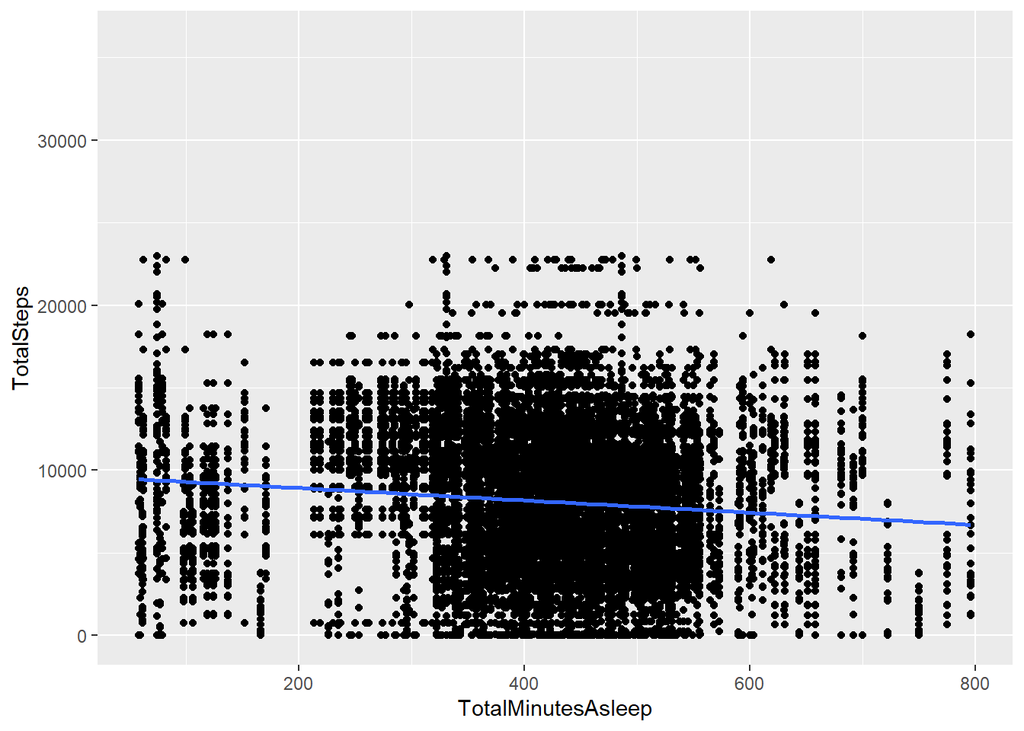

```r
ggplot(combined_data, aes(x=TotalMinutesAsleep, y=TotalSteps)) + geom_point() +
  geom_smooth(formula = y ~ x, method="lm", se=FALSE)
```

```r
# correlation test
cor.test(combined_data$TotalSteps, combined_data$TotalMinutesAsleep)
```

```
##
##  Pearson's product-moment correlation
##
## data:  combined_data$TotalSteps and combined_data$TotalMinutesAsleep
## t = -11.044, df = 12439, p-value < 2.2e-16
## alternative hypothesis: true correlation is not equal to 0
## 95 percent confidence interval:
##  -0.11591302 -0.08110962
## sample estimates:
##         cor
## -0.09854146
```

Participants who sleep more also take fewer steps per day. So the company can use this findings to help inform the marketing strategy of how you position the wellness tracker “Leaf”. This tracker can incorporate notice for woman who sleep more than their needs to be more active during the days to achieve their health and fitness goals.

## Suggestions

- There is a positive relationship between total minutes asleep and total time in bed. The company can use these trends to market the wellness watch “Time” as a way to track total minutes asleep and suggest needed time in bed so that woman can achieve their sleep needs.
- The marketing team can position the “Leaf” tracker as a way to notify woman who sleep more than their needs to be more active during the days to achieve their health and fitness goals.